# DS_Proposal_EDA

```python
import pandas as pd
import matplotlib.pyplot as plt
import scipy.stats as stats
```

```python
from google.colab import drive
drive.mount('/content/drive')
```

```python
file_path = '/content/drive/MyDrive/DS_Pipe/bada_dataset.csv'
```

```python
data = pd.read_csv(file_path)
```

```python
data.head()
```

|  | OBJECTID | FOD_ID | FPA_ID | SOURCE_SYSTEM_TYPE | SOURCE_SYSTEM | NWCG_REPORTING_AGENCY | NWCG_REPORTING_UNIT_ID | NWCG_REPORTING_UNIT_NAME | SOURCE_REPORTING_UNIT | SOURCE_REPORTING_UNIT_NAME | ... | FIRE_SIZE_CLASS | LATITUDE | LONGITUDE | OWNER_CODE | OWNER_DESCR | STATE | COUNTY | FIPS_CODE | FIPS_NAME | Shape |
| --- | --- | --- | --- | --- | --- | --- | --- | --- | --- | --- | --- | --- | --- | --- | --- | --- | --- | --- | --- | --- | --- |
| 0 | 1 | 1 | FS-1418826 | FED | FS-FIRESTAT | FS | USCAPNF | Plumas National Forest | 511 | Plumas National Forest | ... | A | 40.036944 | -121.005833 | 5.0 | USFS | CA | 63.0 | 63.0 | Plumas | b'\x00\x01\xad\x10\x00\x00\xe8d\xc2\x92_@^\xc0... |
| 1 | 2 | 2 | FS-1418827 | FED | FS-FIRESTAT | FS | USCAENF | Eldorado National Forest | 503 | Eldorado National Forest | ... | A | 38.933056 | -120.404444 | 5.0 | USFS | CA | 61.0 | 61.0 | Placer | b'\x00\x01\xad\x10\x00\x00T\xb6\xeej\xe2\x19^\... |
| 2 | 3 | 3 | FS-1418835 | FED | FS-FIRESTAT | FS | USCAENF | Eldorado National Forest | 503 | Eldorado National Forest | ... | A | 38.984167 | -120.735556 | 13.0 | STATE OR PRIVATE | CA | 17.0 | 17.0 | El Dorado | b'\x00\x01\xad\x10\x00\x00\xd0\xa5\xa0W\x13/^\... |
| 3 | 4 | 4 | FS-1418845 | FED | FS-FIRESTAT | FS | USCAENF | Eldorado National Forest | 503 | Eldorado National Forest | ... | A | 38.559167 | -119.913333 | 5.0 | USFS | CA | 3.0 | 3.0 | Alpine | b'\x00\x01\xad\x10\x00\x00\x94\xac\xa3\rt\xfa]... |
| 4 | 5 | 5 | FS-1418847 | FED | FS-FIRESTAT | FS | USCAENF | Eldorado National Forest | 503 | Eldorado National Forest | ... | A | 38.559167 | -119.933056 | 5.0 | USFS | CA | 3.0 | 3.0 | Alpine | b'\x00\x01\xad\x10\x00\x00@\xe3\xaa.\xb7\xfb]\... |

5 rows × 39 columns

FOD_ID = Global unique identifier.

FPA_ID = Unique identifier that contains information necessary to track back to the original record in the source dataset.

SOURCESYSTEMTYPE = Type of source database or system that the record was drawn from (federal, nonfederal, or interagency).

SOURCESYSTEM = Name of or other identifier for source database or system that the record was drawn from.

NWCGREPORTINGAGENCY = Active National Wildlife Coordinating Group (NWCG) Unit Identifier for the agency preparing the fire report

NWCGREPORTINGUNIT_ID = Active NWCG Unit Identifier for the unit preparing the fire report.

NWCGREPORTINGUNIT_NAME = Active NWCG Unit Name for the unit preparing the fire report.

SOURCEREPORTINGUNIT = Code for the agency unit preparing the fire report, based on code/name in the source dataset.

SOURCEREPORTINGUNIT_NAME = Name of reporting agency unit preparing the fire report, based on code/name in the source dataset.

LOCALFIREREPORT_ID = Number or code that uniquely identifies an incident report for a particular reporting unit and a particular calendar year.

LOCALINCIDENTID = Number or code that uniquely identifies an incident for a particular local fire management organization within a particular calendar year.

FIRE_CODE = Code used within the interagency wildland fire community to track and compile cost information for emergency fire suppression (https://www.firecode.gov/).

FIRE_NAME = Name of the incident, from the fire report (primary) or ICS-209 report (secondary).

ICS209INCIDENT_NUMBER = Incident (event) identifier, from the ICS-209 report.

ICS209NAME = Name of the incident, from the ICS-209 report.

MTBS_ID = Incident identifier, from the MTBS perimeter dataset.

MTBSFIRENAME = Name of the incident, from the MTBS perimeter dataset.

COMPLEX_NAME = Name of the complex under which the fire was ultimately managed, when discernible.

FIRE_YEAR = Calendar year in which the fire was discovered or confirmed to exist.

DISCOVERY_DATE = Date on which the fire was discovered or confirmed to exist.

DISCOVERY_DOY = Day of year on which the fire was discovered or confirmed to exist.

DISCOVERY_TIME = Time of day that the fire was discovered or confirmed to exist.

STATCAUSECODE = Code for the (statistical) cause of the fire.

STATCAUSEDESCR = Description of the (statistical) cause of the fire.

CONT_DATE = Date on which the fire was declared contained or otherwise controlled (mm/dd/yyyy where mm=month, dd=day, and yyyy=year).

CONT_DOY = Day of year on which the fire was declared contained or otherwise controlled.

CONT_TIME = Time of day that the fire was declared contained or otherwise controlled (hhmm where hh=hour, mm=minutes).

FIRE_SIZE = Estimate of acres within the final perimeter of the fire.

FIRESIZECLASS = Code for fire size based on the number of acres within the final fire perimeter expenditures (A=greater than 0 but less than or equal to 0.25 acres, B=0.26-9.9 acres, C=10.0-99.9 acres, D=100-299 acres, E=300 to 999 acres, F=1000 to 4999 acres, and G=5000+ acres).

LATITUDE = Latitude (NAD83) for point location of the fire (decimal degrees).

LONGITUDE = Longitude (NAD83) for point location of the fire (decimal degrees).

OWNER_CODE = Code for primary owner or entity responsible for managing the land at the point of origin of the fire at the time of the incident.

OWNER_DESCR = Name of primary owner or entity responsible for managing the land at the point of origin of the fire at the time of the incident.

STATE = Two-letter alphabetic code for the state in which the fire burned (or originated), based on the nominal designation in the fire report.

COUNTY = County, or equivalent, in which the fire burned (or originated), based on nominal designation in the fire report.

FIPS_CODE = Three-digit code from the Federal Information Process Standards (FIPS) publication 6-4 for representation of counties and equivalent entities.

FIPS_NAME = County name from the FIPS publication 6-4 for representation of counties and equivalent entities. NWCGUnitIDActive20170109: Look-up table containing all NWCG identifiers for agency units that were active (i.e., valid) as of 9 January 2017, when the list was downloaded from https://www.nifc.blm.gov/unit_id/Publish.html and used as the source of values available to populate the following fields in the

Fires table: NWCGREPORTINGAGENCY, NWCGREPORTINGUNITID, and NWCGREPORTINGUNITNAME.

UnitId = NWCG Unit ID.

GeographicArea = Two-letter code for the geographic area in which the unit is located

Gacc = Seven or eight-letter code for the Geographic Area Coordination Center in which the unit is located or primarily affiliated with

WildlandRole = Role of the unit within the wildland fire community.

UnitType = Type of unit (e.g., federal, state, local). Department = Department (or state/territory) to which the unit belongs Agency = Agency or bureau to which the unit belongs

Parent = Agency subgroup to which the unit belongs (A concatenation of State and Unit from this report - https://www.nifc.blm.gov/unit_id/publish/UnitIdReport.rtf).

Country = Country in which the unit is located (e.g. US = United States).

State = Two-letter code for the state in which the unit is located (or primarily affiliated).

Code = Unit code (follows state code to create UnitId).

Name = Unit name.

```python
data.columns
```

```
Index(['OBJECTID', 'FOD_ID', 'FPA_ID', 'SOURCE_SYSTEM_TYPE', 'SOURCE_SYSTEM',
       'NWCG_REPORTING_AGENCY', 'NWCG_REPORTING_UNIT_ID',
       'NWCG_REPORTING_UNIT_NAME', 'SOURCE_REPORTING_UNIT',
       'SOURCE_REPORTING_UNIT_NAME', 'LOCAL_FIRE_REPORT_ID',
       'LOCAL_INCIDENT_ID', 'FIRE_CODE', 'FIRE_NAME',
       'ICS_209_INCIDENT_NUMBER', 'ICS_209_NAME', 'MTBS_ID', 'MTBS_FIRE_NAME',
       'COMPLEX_NAME', 'FIRE_YEAR', 'DISCOVERY_DATE', 'DISCOVERY_DOY',
       'DISCOVERY_TIME', 'STAT_CAUSE_CODE', 'STAT_CAUSE_DESCR', 'CONT_DATE',
       'CONT_DOY', 'CONT_TIME', 'FIRE_SIZE', 'FIRE_SIZE_CLASS', 'LATITUDE',
       'LONGITUDE', 'OWNER_CODE', 'OWNER_DESCR', 'STATE', 'COUNTY',
       'FIPS_CODE', 'FIPS_NAME', 'Shape'],
      dtype='object')
```

```python
pruned_data = data.drop(columns = ['OBJECTID', 'FPA_ID', 'SOURCE_SYSTEM',
       'NWCG_REPORTING_UNIT_ID',
       'NWCG_REPORTING_UNIT_NAME', 'SOURCE_REPORTING_UNIT',
       'SOURCE_REPORTING_UNIT_NAME', 'LOCAL_FIRE_REPORT_ID',
       'LOCAL_INCIDENT_ID', 'FIRE_CODE', 'FIRE_NAME',
       'ICS_209_INCIDENT_NUMBER', 'ICS_209_NAME', 'MTBS_ID', 'MTBS_FIRE_NAME',
       'COMPLEX_NAME', 'STAT_CAUSE_CODE','OWNER_CODE', 'FIPS_NAME','FIPS_CODE', 'Shape'])
```

```python
pruned_data.head()
```

|  | FOD_ID | SOURCE_SYSTEM_TYPE | NWCG_REPORTING_AGENCY | FIRE_YEAR | DISCOVERY_DATE | DISCOVERY_DOY | DISCOVERY_TIME | STAT_CAUSE_DESCR | CONT_DATE | CONT_DOY | CONT_TIME | FIRE_SIZE | FIRE_SIZE_CLASS | LATITUDE | LONGITUDE | OWNER_DESCR | STATE | COUNTY |
| --- | --- | --- | --- | --- | --- | --- | --- | --- | --- | --- | --- | --- | --- | --- | --- | --- | --- | --- |
| 0 | 1 | FED | FS | 2005 | 2453403.5 | 33 | 1300.0 | Miscellaneous | 2453403.5 | 33.0 | 1730.0 | 0.10 | A | 40.036944 | -121.005833 | USFS | CA | 63.0 |
| 1 | 2 | FED | FS | 2004 | 2453137.5 | 133 | 845.0 | Lightning | 2453137.5 | 133.0 | 1530.0 | 0.25 | A | 38.933056 | -120.404444 | USFS | CA | 61.0 |
| 2 | 3 | FED | FS | 2004 | 2453156.5 | 152 | 1921.0 | Debris Burning | 2453156.5 | 152.0 | 2024.0 | 0.10 | A | 38.984167 | -120.735556 | STATE OR PRIVATE | CA | 17.0 |
| 3 | 4 | FED | FS | 2004 | 2453184.5 | 180 | 1600.0 | Lightning | 2453189.5 | 185.0 | 1400.0 | 0.10 | A | 38.559167 | -119.913333 | USFS | CA | 3.0 |
| 4 | 5 | FED | FS | 2004 | 2453184.5 | 180 | 1600.0 | Lightning | 2453189.5 | 185.0 | 1200.0 | 0.10 | A | 38.559167 | -119.933056 | USFS | CA | 3.0 |

```python
columns = ['SOURCE_SYSTEM_TYPE', 'NWCG_REPORTING_AGENCY', 'STAT_CAUSE_DESCR','FIRE_SIZE_CLASS','OWNER_DESCR', 'STATE']

#NWCG_REPORTING_AGENCY is not satisfying both ANOVA assumptions
```

[output not shown]

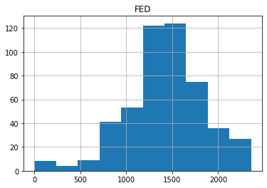

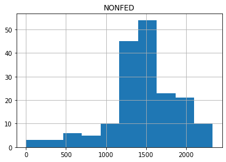

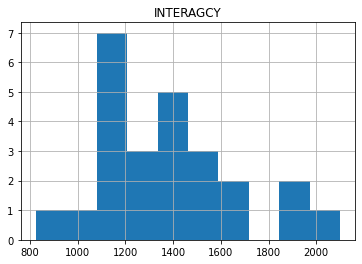

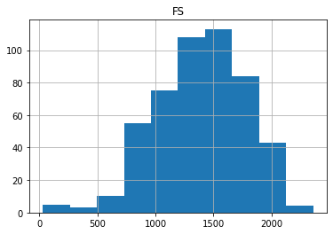

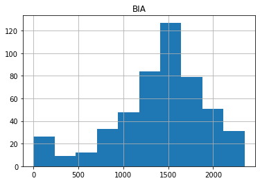

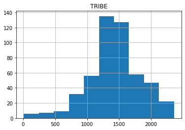

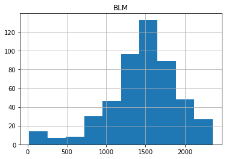

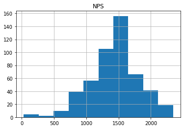

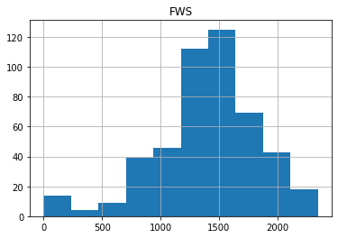

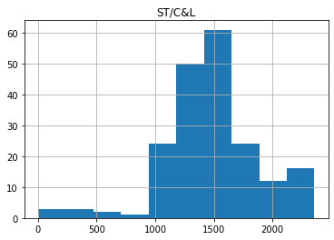

[figure not shown]

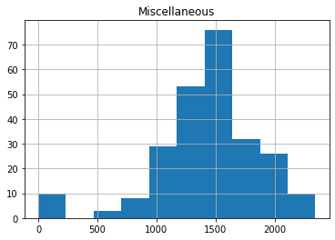

[81 more figures not shown]

```python
#checking which featuers are satisfying anova assumptions - normality check
for column in columns:
  sub_classes = pruned_data[column].unique()
  for classs in sub_classes:
    data = pruned_data[pruned_data[column] == classs]
    if len(data) > 500:
      data = data.sample(n=500,random_state=2)
      data['DISCOVERY_TIME'].hist()
      plt.title(classs)
      plt.show()
```

```python
# STD deviation anova assumption check
for column in columns:
  #sub_classes = pruned_data[column].unique()
  #data = pruned_data[pruned_data[column] == classs]
  #data['DISCOVERY_TIME'].std()
  #data = pruned_data.sample(n=1000,random_state = 32)
  stdn = pruned_data.groupby(column)['DISCOVERY_TIME'].std()
  print(column)
  print(stdn.max()/stdn.min())
```

```
SOURCE_SYSTEM_TYPE
1.1627263623059136
NWCG_REPORTING_AGENCY
7.540597160474748
STAT_CAUSE_DESCR
1.7297721904204135
FIRE_SIZE_CLASS
1.2085978093518392
OWNER_DESCR
1.7712679779826088
STATE
2.104709682145897
```

```python
column = 'NWCG_REPORTING_AGENCY'
sub_classes = pruned_data[column].unique()
print(sub_classes)
```

```
['FS' 'BIA' 'TRIBE' 'BLM' 'NPS' 'BOR' 'FWS' 'ST/C&L' 'DOD' 'IA' 'DOE']
```

```python
#perofrming the anova test to find the p value
temp_data = pruned_data.dropna(subset=['DISCOVERY_TIME'],inplace=False)
columns = ['STAT_CAUSE_DESCR','FIRE_SIZE_CLASS','OWNER_DESCR','STATE','SOURCE_SYSTEM_TYPE']
for column in columns:
  x = []
  for classs in temp_data[column].unique():
    x.append(list(temp_data[temp_data[column] == classs].DISCOVERY_TIME))
  fvalue, pvalue = stats.f_oneway(*x)
  print(column,fvalue, pvalue)
#all columms tested above have statistically significant influence on Discovery time
# We will be using these five columns to impute Discovery Time
```

```
STAT_CAUSE_DESCR 636.1309310239039 0.0
FIRE_SIZE_CLASS 89.96985522257222 2.374756040033945e-113
OWNER_DESCR 521.5518859428198 0.0
STATE 260.5683331419481 0.0
SOURCE_SYSTEM_TYPE 1238.984451390644 0.0
```

```python
# dropping na data for now to perform EDA
for column in pruned_data.columns:
  if (pruned_data[column].isna().any()):
    print(column,'is na ',pruned_data[column].isna().sum()/len(pruned_data),'')
# count of na datapoints
for column in pruned_data.columns:
  if (pruned_data[column].isna().any()):
    print(column,'is na ',pruned_data[column].isna().sum(),'')
```

```
DISCOVERY_TIME is na  0.46937220315188
CONT_DATE is na  0.47410135259098146
CONT_DOY is na  0.47410135259098146
CONT_TIME is na  0.5171875041545575
COUNTY is na  0.3606278234372881
DISCOVERY_TIME is na  882638
CONT_DATE is na  891531
CONT_DOY is na  891531
CONT_TIME is na  972553
COUNTY is na  678148
```

```python
dropped_data = pruned_data.dropna()
print(len(dropped_data)/len(pruned_data))
```

```
0.309050686931158
```

```python
print(len(dropped_data))
```

```
581159
```

```python
pruned_data['fire_duration'] = pruned_data['CONT_DOY'] - pruned_data['DISCOVERY_DOY']
```

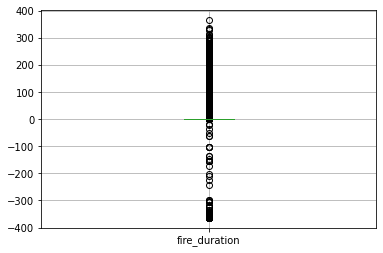

```python
pruned_data.boxplot(column=['fire_duration'])
```

```python
pruned_data.head()
```

|  | FOD_ID | SOURCE_SYSTEM_TYPE | NWCG_REPORTING_AGENCY | FIRE_YEAR | DISCOVERY_DATE | DISCOVERY_DOY | DISCOVERY_TIME | STAT_CAUSE_DESCR | CONT_DATE | CONT_DOY | CONT_TIME | FIRE_SIZE | FIRE_SIZE_CLASS | LATITUDE | LONGITUDE | OWNER_DESCR | STATE | COUNTY | fire_duration |
| --- | --- | --- | --- | --- | --- | --- | --- | --- | --- | --- | --- | --- | --- | --- | --- | --- | --- | --- | --- |
| 0 | 1 | FED | FS | 2005 | 2453403.5 | 33 | 1300.0 | Miscellaneous | 2453403.5 | 33.0 | 1730.0 | 0.10 | A | 40.036944 | -121.005833 | USFS | CA | 63.0 | 0.0 |
| 1 | 2 | FED | FS | 2004 | 2453137.5 | 133 | 845.0 | Lightning | 2453137.5 | 133.0 | 1530.0 | 0.25 | A | 38.933056 | -120.404444 | USFS | CA | 61.0 | 0.0 |
| 2 | 3 | FED | FS | 2004 | 2453156.5 | 152 | 1921.0 | Debris Burning | 2453156.5 | 152.0 | 2024.0 | 0.10 | A | 38.984167 | -120.735556 | STATE OR PRIVATE | CA | 17.0 | 0.0 |
| 3 | 4 | FED | FS | 2004 | 2453184.5 | 180 | 1600.0 | Lightning | 2453189.5 | 185.0 | 1400.0 | 0.10 | A | 38.559167 | -119.913333 | USFS | CA | 3.0 | 5.0 |
| 4 | 5 | FED | FS | 2004 | 2453184.5 | 180 | 1600.0 | Lightning | 2453189.5 | 185.0 | 1200.0 | 0.10 | A | 38.559167 | -119.933056 | USFS | CA | 3.0 | 5.0 |

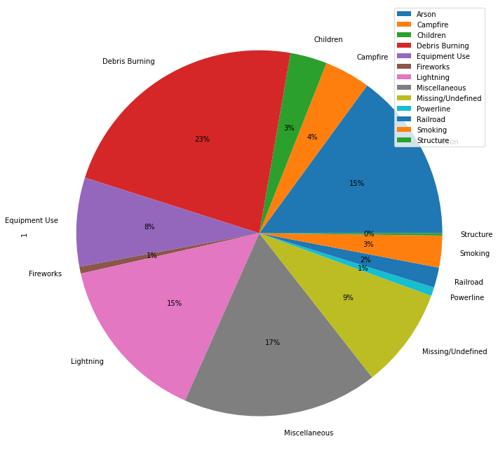

```python
temp_data = pruned_data[:]
temp_data['1'] = 1
temp_data.groupby(['STAT_CAUSE_DESCR']).sum().plot(kind='pie', y='1', autopct='%1.0f%%',figsize=(12, 12))
```

```python
corr_matrix = pruned_data.drop(columns=['fire_duration']).corr()
corr_matrix.style.background_gradient(cmap='Reds')
```

|  | FOD_ID | FIRE_YEAR | DISCOVERY_DATE | DISCOVERY_DOY | DISCOVERY_TIME | CONT_DATE | CONT_DOY | CONT_TIME | FIRE_SIZE | LATITUDE | LONGITUDE |
| --- | --- | --- | --- | --- | --- | --- | --- | --- | --- | --- | --- |
| FOD_ID | 1.000000 | 0.683548 | 0.682485 | -0.022077 | 0.031819 | 0.749375 | -0.058620 | 0.025938 | 0.002855 | -0.089132 | -0.041952 |
| FIRE_YEAR | 0.683548 | 1.000000 | 0.999316 | -0.008885 | 0.030543 | 0.999495 | -0.005300 | 0.019465 | 0.007048 | 0.000407 | 0.015863 |
| DISCOVERY_DATE | 0.682485 | 0.999316 | 1.000000 | 0.028105 | 0.029262 | 0.999983 | 0.025711 | 0.018723 | 0.007260 | 0.005821 | 0.006870 |
| DISCOVERY_DOY | -0.022077 | -0.008885 | 0.028105 | 1.000000 | -0.039945 | 0.020174 | 0.994455 | -0.023590 | 0.005810 | 0.146405 | -0.243033 |
| DISCOVERY_TIME | 0.031819 | 0.030543 | 0.029262 | -0.039945 | 1.000000 | 0.027724 | -0.041970 | 0.549620 | 0.000982 | 0.021728 | 0.063089 |
| CONT_DATE | 0.749375 | 0.999495 | 0.999983 | 0.020174 | 0.027724 | 1.000000 | 0.026053 | 0.018590 | 0.007157 | 0.053056 | 0.064048 |
| CONT_DOY | -0.058620 | -0.005300 | 0.025711 | 0.994455 | -0.041970 | 0.026053 | 1.000000 | -0.027152 | 0.023466 | 0.165286 | -0.279124 |
| CONT_TIME | 0.025938 | 0.019465 | 0.018723 | -0.023590 | 0.549620 | 0.018590 | -0.027152 | 1.000000 | -0.001539 | -0.012641 | 0.024545 |
| FIRE_SIZE | 0.002855 | 0.007048 | 0.007260 | 0.005810 | 0.000982 | 0.007157 | 0.023466 | -0.001539 | 1.000000 | 0.038860 | -0.039731 |
| LATITUDE | -0.089132 | 0.000407 | 0.005821 | 0.146405 | 0.021728 | 0.053056 | 0.165286 | -0.012641 | 0.038860 | 1.000000 | -0.354727 |
| LONGITUDE | -0.041952 | 0.015863 | 0.006870 | -0.243033 | 0.063089 | 0.064048 | -0.279124 | 0.024545 | -0.039731 | -0.354727 | 1.000000 |

```python
pruned_data['FIRE TIME'] = pruned_data['CONT_DATE']- pruned_data['DISCOVERY_DATE']
```

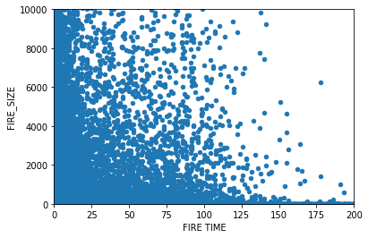

```python
pruned_data.plot.scatter(x = 'FIRE TIME', y = 'FIRE_SIZE',ylim= (0,10000),xlim=(0,200))
```

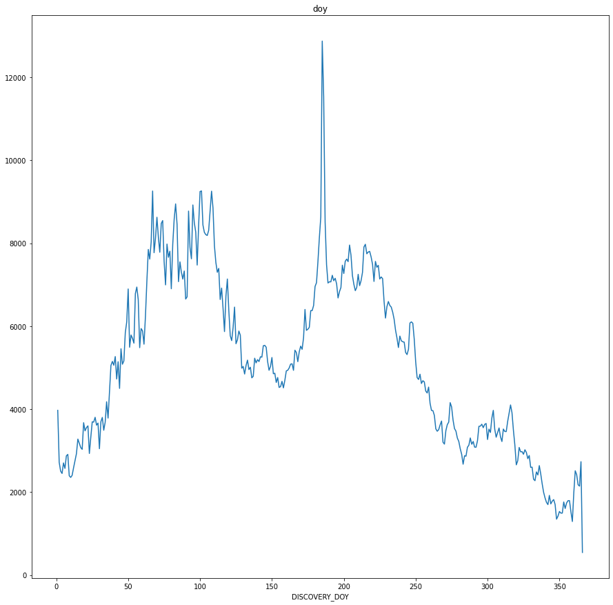

```python
dfg = temp_data.groupby(['DISCOVERY_DOY'])['1'].sum()
dfg.plot(title='doy', figsize=(15, 15))
```

```python
temp_data['MONTH'] = 1
```

```python
import calendar

def JulianDate_to_MMDDYY(row):
    month = 1
    day = 0
    while row['DISCOVERY_DOY'] - calendar.monthrange(row['FIRE_YEAR'],month)[1] > 0 and month <= 12:
        row['DISCOVERY_DOY'] = row['DISCOVERY_DOY'] - calendar.monthrange(row['FIRE_YEAR'],month)[1]
        month = month + 1
    return month
```

```python
temp_data['MONTH'] = temp_data.apply(JulianDate_to_MMDDYY, axis = 1)
```

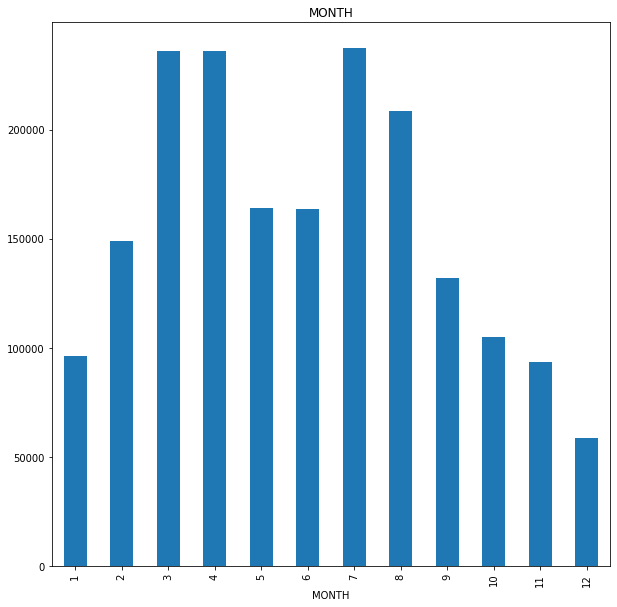

```python
dfg = temp_data.groupby(['MONTH'])['1'].sum()
dfg.plot(kind = 'bar', title='MONTH', figsize=(10, 10))
```

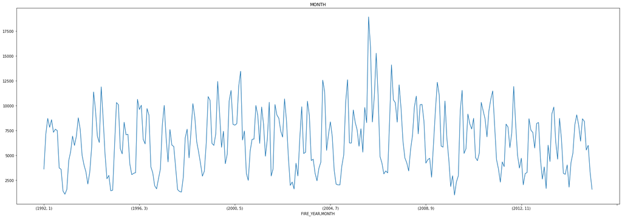

```python
dfg = temp_data.groupby(['FIRE_YEAR','MONTH'])['1'].sum()
plt = dfg.plot(title='MONTH', figsize=(30, 10))
```

[figure not shown]

```python
dfg = temp_data.groupby(['FIRE_YEAR'])['1'].sum()
plt = dfg.plot(kind='hist',title='Year', figsize=(60, 50))
```

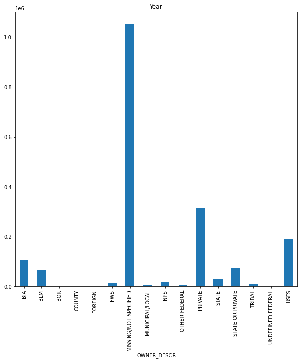

```python
dfg = temp_data.groupby(['OWNER_DESCR'])['1'].sum()
plt = dfg.plot(kind='bar',title='Year', figsize=(10, 10))
```

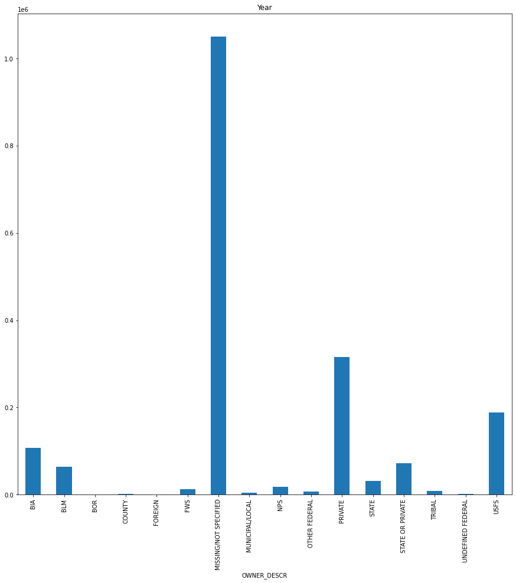

```python
dfg = temp_data.groupby(['OWNER_DESCR'])['1'].sum()
plt = dfg.plot(kind='bar',title='Year', figsize=(15, 15))
```

```python
temp_temp_data = temp_data[:]
```

```python
import numpy as np
import matplotlib.pyplot as plt
x,y = np.meshgrid(['OWNER_DESCR','FIRE_SIZE_CLASS'], [0,1])

temp_temp_data *= 5000
plt.scatter(x=x.flatten(), y=y.flatten(), s=temp_data.values.flatten())
plt.margins(.4)
plt.show()
```

[output not shown]